# Equações Estruturais

05/01/2020

## Equações Estruturais: Segmentação de Mercado

- O objetivo é segmentar os consumidores de três marcas de refrigerante (Coca, Fanta, Sprite) a partir de três variáveis latentes (**constructos**). Neste exemplo os constructos são: **Sabor**, **Saude**, **Sede**.
- Os constructos serão medidos a partir de diferentes variáveis observáveis: *X1, …, X7* (*itens*). Neste exemplo os ítens são provenientes das respostas às perguntas de um questionário.
  - **Sabor**
    - *X1*. A marca Y tem um sabor refrescante
    - *X4*. Eu gosto do sabor suave da marca Y
    - *X6*. A marca Y tem sabor único
  - **Saude**
    - *X2*. Eu prefiro a marca Y porque tem menos calorias que outras bebidas
    - *X5*. Eu prefiro tomar a marca Y após os exercícios e esportes porque ela me dá energia
  - **Sede**
    - *X3*. A marca Y sacia minha sede imediatamente
    - *X7*. Eu prefiro tomar a marca Y quando eu estou com muita sede

## Tipos de constructos, escalas de itens

- Os constructos são ditos *refletivos* se eles causam a ocorrência de um ítem.
- No caso inverso, quando o ítem causa o constructo eles são chamados de *formativos*
- Para aplicar o método das equações estruturais, as escalas nas quais os ítens serão medidos deverão sempre ser diretas, isto é, quanto maior o valor dado na escala, maior é a influência positiva do ítem no constructo e vice versa.
- A escala típica utilizada para medir um ítem é a chamada *Escala Likert*. No exemplo deste exercício, os ítens X1 a X7 foram medidos em uma escala Likert de 1 até 7.

## Base de dados

A base de dados pode ser vista a seguir. O arquivo `refri.csv` deverá estar disponível no diretório de trabalho do R/RStudio

```r
refri <- read.csv2("https://raw.githubusercontent.com/gustavomirapalheta/classes_datasets/master/refri.csv");
refri <- dplyr::as_tibble(refri); refri
```

```
## # A tibble: 48 x 9
##    MARCA  Cod_respondente    X1    X2    X3    X4    X5    X6    X7
##    <fct>            <int> <int> <int> <int> <int> <int> <int> <int>
##  1 Coca                 1     4     3     5     3     3     3     4
##  2 Fanta                1     4     5     6     4     5     4     5
##  3 Sprite               1     7     6     6     6     7     6     5
##  4 Coca                 2     7     4     4     6     4     7     5
##  5 Fanta                2     4     5     7     3     4     3     7
##  6 Sprite               2     7     5     5     7     6     6     5
##  7 Coca                 3     5     2     2     6     1     6     2
##  8 Fanta                3     2     4     7     2     5     3     7
##  9 Sprite               3     5     7     6     5     7     5     6
## 10 Coca                 4     4     3     3     5     2     5     3
## # … with 38 more rows
```

## Confirmação de dimensionalidade

Primeiro é necessário confirmar se, a maior parte da informação obtida através dos itens pode ser representada por três *Componentes Principais*.

```r
fit = princomp(refri[ ,3:9], cor = TRUE); summary(fit)
```

```
## Importance of components:
##                        Comp.1 Comp.2 Comp.3 Comp.4 Comp.5 Comp.6  Comp.7
## Standard deviation      1.840  1.586  0.861 0.3586 0.3113 0.2808 0.23524
## Proportion of Variance  0.484  0.359  0.106 0.0184 0.0138 0.0113 0.00791
## Cumulative Proportion   0.484  0.843  0.949 0.9670 0.9808 0.9921 1.00000
```

Observe a linha *Cumulative Proportion* acima.

Por ela percebe-se que os três componentes com as maiores variâncias “explicam” quase 95% da variância total da base de dados.

## Confirmação de dimensionalidade, gráfico

O gráfico a seguir apresenta a variância de cada componente em ordem decrescente

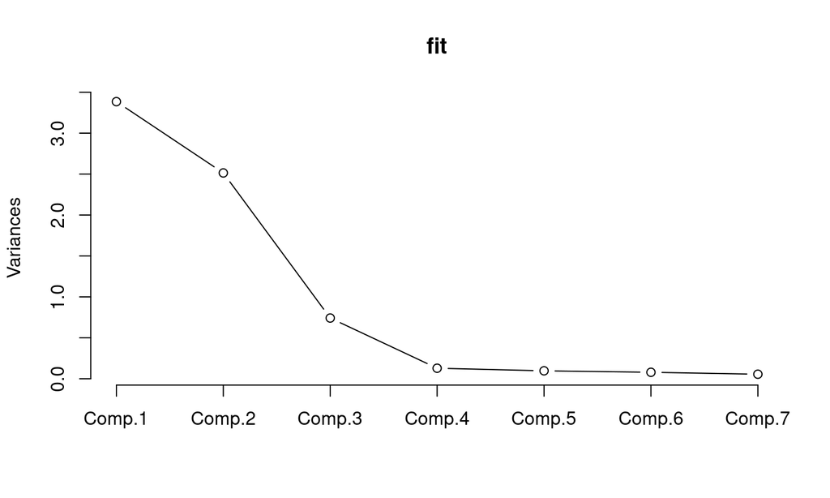

```r
plot(fit, type="lines")
```

## Confirmação de dimensionalidade, ggplot2

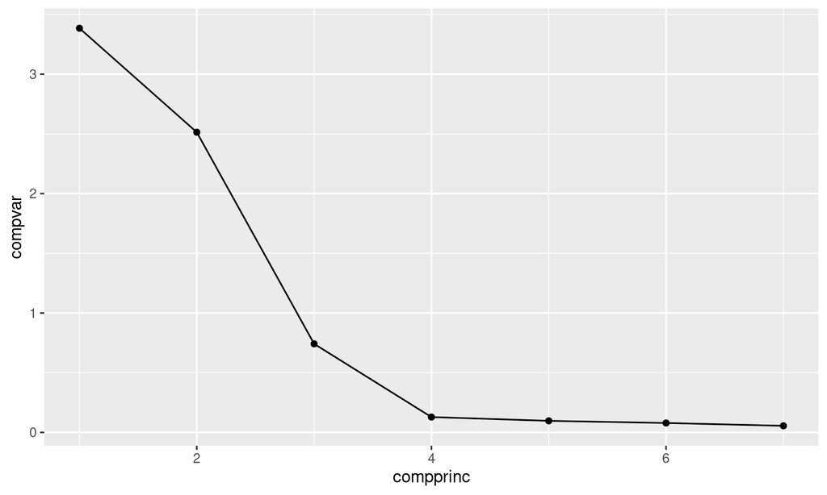

```r
library(dplyr); library(ggplot2)
compvar_tibble <- tibble(compprinc = 1:length(fit$sdev^2), compvar = fit$sdev^2)
ggplot(compvar_tibble, aes(x=compprinc, y=compvar)) + geom_point() + geom_line()
```

## Validade convergente: item x constructo

```r
cargas = psych::principal(refri[ ,3:9], nfactors = 3, rotate = "varimax"); cargas$loadings
```

```
##
## Loadings:
##    RC1    RC2    RC3
## X1  0.887  0.204 -0.288
## X2         0.960  0.218
## X3 -0.219  0.349  0.886
## X4  0.970
## X5  0.106  0.938  0.274
## X6  0.944        -0.202
## X7 -0.221  0.219  0.929
##
##                 RC1   RC2   RC3
## SS loadings    2.73 2.014 1.898
## Proportion Var 0.39 0.288 0.271
## Cumulative Var 0.39 0.677 0.949
```

## Validade discriminante: item x demais constr.

Em seguida determinamos para cada item, se a correlação dele com os demais constructos está abaixo de 40%. Isto pode ser confirmado na tabela anterior (apresentada novamente abaixo). Sendo assim dizemos que foi atendido o critério da validação discriminante.

```r
cargas = psych::principal(refri[ ,3:9], nfactors = 3, rotate = "varimax"); cargas$loadings
```

```
##
## Loadings:
##    RC1    RC2    RC3
## X1  0.887  0.204 -0.288
## X2         0.960  0.218
## X3 -0.219  0.349  0.886
## X4  0.970
## X5  0.106  0.938  0.274
## X6  0.944        -0.202
## X7 -0.221  0.219  0.929
##
##                 RC1   RC2   RC3
## SS loadings    2.73 2.014 1.898
## Proportion Var 0.39 0.288 0.271
## Cumulative Var 0.39 0.677 0.949
```

## Confiabilidade dos itens: Alpha de Cronbach

A confiabilidade diz respeito a quão dispersas estão as medidas obtidas pelos itens de um constructo. Observe que confiabilidade não implica em validade. Validade diz respeito a encontrar o valor correto, com medidas mesmo que dispersas (pouco confiáveis).

Para cada constructo é calculado um Alpha de Cronbach, que dirá se os itens apresentam medidas confiáveis ou não. Os critérios de valores são obtidos da seguinte escala:

\[ \alpha ≥ 0,9 : \text{Excelente} \] \[ 0,9 > \alpha ≥ 0,8 : \text{Bom} \] \[ 0,8 > \alpha ≥ 0,7 : \text{Aceitável} \] \[ 0,7 > \alpha ≥ 0,6 : \text{Questionável} \] \[ 0,6 > \alpha ≥ 0,5 : Fraco \] \[ 0,5 > \alpha : \text{Não aceitável} \]

## Confiabilidade dos itens: Alpha de Cronbach

O cálculo do Alpha de Cronbach para os ítens de cada constructo é feito de acordo com a seguinte fórmula:

\[ \alpha = \frac{k}{k-1} \left( 1 - \frac{\sum{{s^2}_i}}{{s^2}_t} \right) \]

Onde:

- \(k\) é o número de itens no constructo,
- \({s^2}_i\) é a variância dos valores do ítem \(i\) e
- \({s^2}_t\) é a variância da soma de cada linha dos itens do constructo.

No slide a seguir vamos montar um data frame para calcular o Alpha de Cronbach de cada constructo.

## Confiabilidade dos itens: Alpha de Cronbach

A função a seguir calcula o alpha de Cronbach para um dataframe. Em seguida criamos três dataframes, um para cada constructo, a partir dos itens correspondentes. Por último utilizamos sapply para calcular o alpha de Cronbach de cada dataframe (isto é de cada constructo).

```r
alpha_cron <- function(df){
  var_i <- apply(df, 2, var); svar_i = sum(var_i)
  src1 <- apply(df,1,sum); svar_t = var(src1)
  k = length(df)
  alpha = k/(k-1) * (1 - svar_i/svar_t)
  return(alpha) }

rc1 <- tibble(refri$X1, refri$X4, refri$X6);
rc2 <- tibble(refri$X2, refri$X5)
rc3 <- tibble(refri$X3, refri$X7)

rc = list(rc1, rc2, rc3); sapply(rc, alpha_cron)
```

```
## [1] 0.948 0.964 0.952
```

## Modelo de Equações Estruturais: Notação

O objetivo do modelo de equações estruturais é entender a existência de possíveis relacionamentos entre as variáveis observáveis (itens) e as variáveis latentes (constructos)

- A notação utilizada na montagem de um modelo é
  - *variável latente =~ item1 + item2 + item3*, onde *=~* significa *é mensurada por*
  - *~* significa *está relacionado com* e indica uma regressão
  - *~~* significa *está correlacionado com* e indica uma covariância
  - *~1* indica *intercepto*
- Neste exemplo o iremos testar:
  - *Sabor =~ X1 + X4 + X6*
  - *Saude =~ X2 + X5*
  - *Sede =~ X3 + X7*

## Modelo de Equações Estruturais: Montagem

Os resultados são detalhados no próximo slide

```r
modelo ='
 sabor =~ X4 + X1 + X6
 saude =~ X5  + X2
 sede =~ X3 + X7
'
refri_result <- lavaan::sem(modelo, data=refri); refri_result
```

```
## lavaan 0.6-9 ended normally after 51 iterations
##
##   Estimator                                         ML
##   Optimization method                           NLMINB
##   Number of model parameters                        17
##
##   Number of observations                            48
##
## Model Test User Model:
##
##   Test statistic                                20.768
##   Degrees of freedom                                11
##   P-value (Chi-square)                           0.036
```

## Modelo de Equações Estruturais: Resultados

A função a seguir apresenta todas as informações do modelo de variáveis estruturais. Como o relatório é extenso demais para apresentar em um único slide, serão apresentados resultados parciais a seguir

```
## lavaan 0.6-9 ended normally after 51 iterations
##
##   Estimator                                         ML
##   Optimization method                           NLMINB
##   Number of model parameters                        17
##
##   Number of observations                            48
##
## Model Test User Model:
##
##   Test statistic                                20.768
##   Degrees of freedom                                11
##   P-value (Chi-square)                           0.036
##
## Parameter Estimates:
##
##   Standard errors                             Standard
##   Information                                 Expected
##   Information saturated (h1) model          Structured
##
## Latent Variables:
##                    Estimate  Std.Err  z-value  P(>|z|)   Std.lv  Std.all
##   sabor =~
##     X4                1.000                               1.363    0.926
##     X1                0.923    0.088   10.534    0.000    1.258    0.899
##     X6                0.908    0.071   12.707    0.000    1.237    0.963
##   saude =~
##     X5                1.000                               1.727    1.007
##     X2                0.823    0.072   11.414    0.000    1.421    0.930
##   sede =~
##     X3                1.000                               1.541    1.013
##     X7                0.828    0.082   10.107    0.000    1.275    0.899
##
## Covariances:
##                    Estimate  Std.Err  z-value  P(>|z|)   Std.lv  Std.all
##   sabor ~~
##     saude             0.230    0.346    0.664    0.507    0.098    0.098
##     sede             -0.756    0.327   -2.315    0.021   -0.360   -0.360
##   saude ~~
##     sede              1.413    0.428    3.301    0.001    0.531    0.531
##
## Variances:
##                    Estimate  Std.Err  z-value  P(>|z|)   Std.lv  Std.all
##    .X4                0.307    0.093    3.292    0.001    0.307    0.142
##    .X1                0.374    0.097    3.864    0.000    0.374    0.191
##    .X6                0.121    0.062    1.963    0.050    0.121    0.073
##    .X5               -0.039    0.204   -0.189    0.850   -0.039   -0.013
##    .X2                0.313    0.152    2.059    0.039    0.313    0.134
##    .X3               -0.062    0.172   -0.360    0.719   -0.062   -0.027
##    .X7                0.387    0.142    2.728    0.006    0.387    0.192
##     sabor             1.858    0.443    4.195    0.000    1.000    1.000
##     saude             2.981    0.634    4.701    0.000    1.000    1.000
##     sede              2.374    0.502    4.728    0.000    1.000    1.000
```

## Modelo de Equações Estruturais: Var.Latentes

A seguir são apresentados os resultados das variáveis latentes. O software sempre fixa uma relação de 1 para 1 com alguma variável. Neste caso: em sabor: X4, em saúde: X5, em sede: X3. Os outros valores são analisados como os impactos de cada variável sobre os constructos.

```r
refri_params <- as_tibble(lavaan::parameterEstimates(refri_result, standardized=TRUE))
refri_params[1:7,1:4]
```

```
## # A tibble: 7 x 4
##   lhs   op    rhs     est
##   <chr> <chr> <chr> <dbl>
## 1 sabor =~    X4    1
## 2 sabor =~    X1    0.923
## 3 sabor =~    X6    0.908
## 4 saude =~    X5    1
## 5 saude =~    X2    0.823
## 6 sede  =~    X3    1
## 7 sede  =~    X7    0.828
```

## Modelo de Equações Estruturais: Covariâncias

A próxima análise é feita com base na covariância entre as variáveis latentes (construtos). Exemplos: Entre sabor e saúde: valor-p = 0,507 (irrelevante), entre sabor e sede: valor-p = 0,021 (relevante) e entre saúde e sede: valor-p = 0,001 (relevante).

```r
refri_params <- as_tibble(lavaan::parameterEstimates(refri_result, standardized=TRUE))
refri_params[18:20,1:7]
```

```
## # A tibble: 3 x 7
##   lhs   op    rhs      est    se      z   pvalue
##   <chr> <chr> <chr>  <dbl> <dbl>  <dbl>    <dbl>
## 1 sabor ~~    saude  0.230 0.346  0.664 0.507
## 2 sabor ~~    sede  -0.756 0.327 -2.31  0.0206
## 3 saude ~~    sede   1.41  0.428  3.30  0.000963
```

## Modelo de Segmentação: Dendrograma

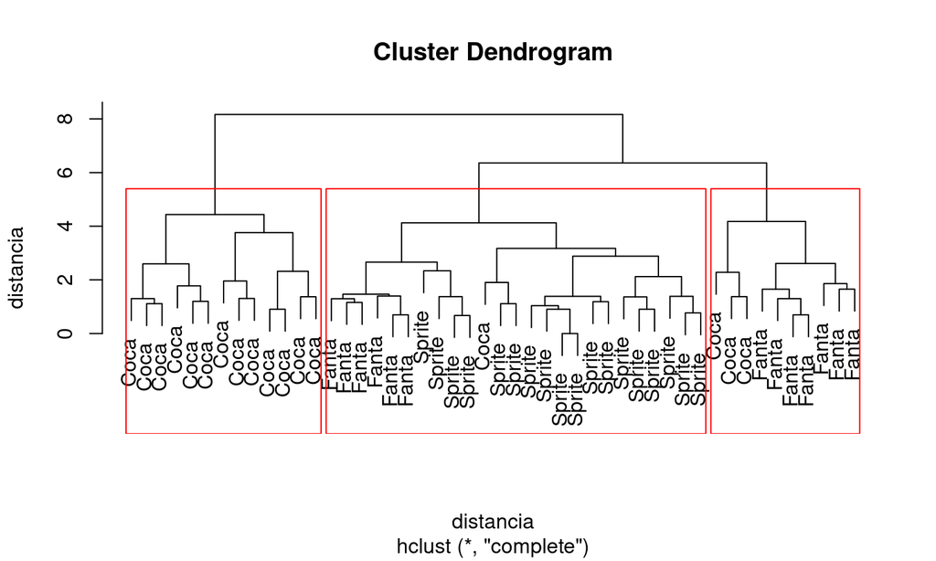

```r
objetos = refri$MARCA; distancia = dist(scale(refri[,3:9]))
h  = hclust(distancia); plot(h, labels = objetos, ylab='distancia'); rect.hclust(h,3)
```

## Modelo de Segmentação: Inclusão dos Clusters

```r
grupos = kmeans(refri[,3:9],3); grupo = as.factor(grupos$cluster)
matriz = dplyr::mutate(refri, cluster = grupo); matriz
```

```
## # A tibble: 48 x 10
##    MARCA  Cod_respondente    X1    X2    X3    X4    X5    X6    X7 cluster
##    <fct>            <int> <int> <int> <int> <int> <int> <int> <int> <fct>
##  1 Coca                 1     4     3     5     3     3     3     4 3
##  2 Fanta                1     4     5     6     4     5     4     5 3
##  3 Sprite               1     7     6     6     6     7     6     5 2
##  4 Coca                 2     7     4     4     6     4     7     5 2
##  5 Fanta                2     4     5     7     3     4     3     7 3
##  6 Sprite               2     7     5     5     7     6     6     5 2
##  7 Coca                 3     5     2     2     6     1     6     2 1
##  8 Fanta                3     2     4     7     2     5     3     7 3
##  9 Sprite               3     5     7     6     5     7     5     6 2
## 10 Coca                 4     4     3     3     5     2     5     3 1
## # … with 38 more rows
```

## Modelo de Segmentação: Visualiz.dos Clusters

Saude x sabor: com a baixa correlação (valor-p = 0,507), a separação dos clusters fica evidente neste caso.

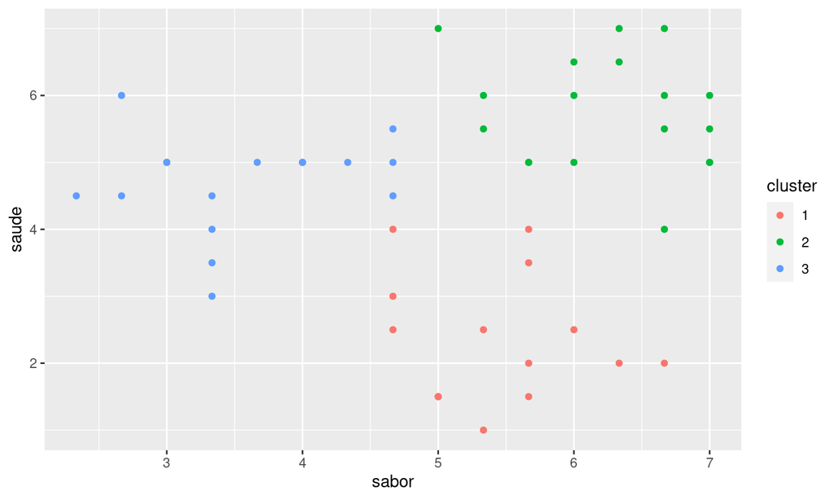

```r
matriz2 <- dplyr::mutate(matriz, sabor=(X1+X4+X6)/3, saude=(X2+X5)/2, sede=(X3+X7)/2)
ggplot(matriz2, aes(x=sabor, y=saude)) + geom_point(aes(color=cluster))
```

## Modelo de Segmentação: Visualiz.dos Clusters

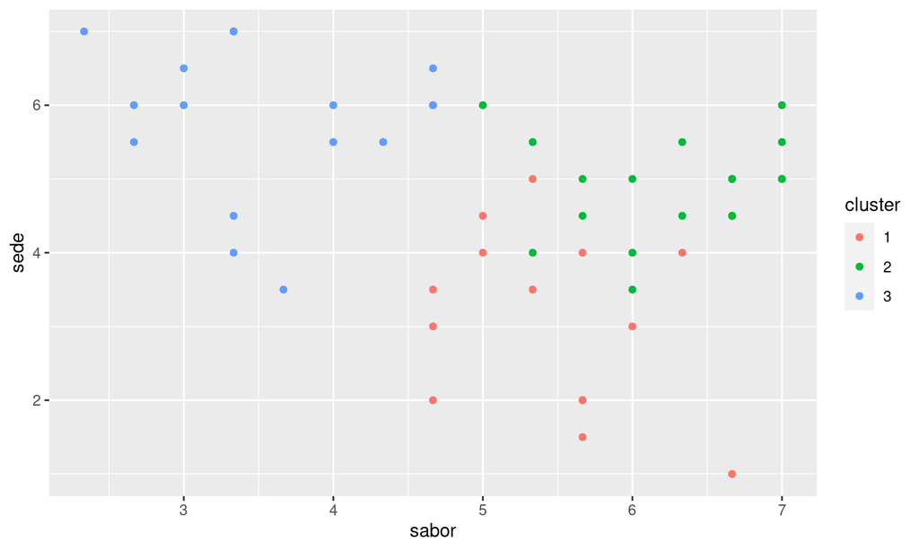

```r
ggplot(matriz2, aes(x=sabor, y=sede)) + geom_point(aes(color=cluster))
```

## Modelo de Segmentação: Visualiz.dos Clusters

Saude x Sede: uma vez que neste caso o p-value foi o menor de todos (valor-p = 0,001), não é possível a clara separação dos clusters.

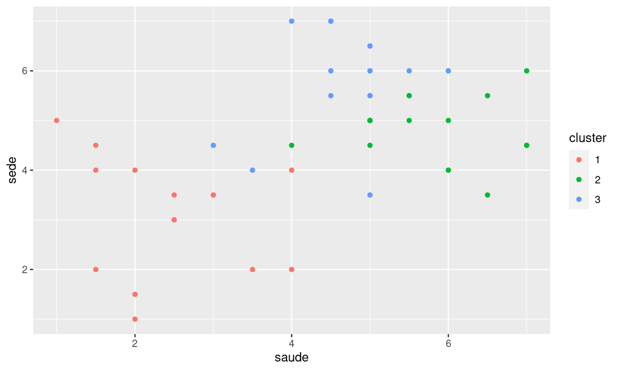

```r
ggplot(matriz2, aes(x=saude, y=sede)) + geom_point(aes(color=cluster))
```